# **1 - Problem Statement**

## **Business Context**

Workplace safety in hazardous environments like construction sites and industrial plants is crucial to prevent accidents and injuries. One of the most important safety measures is ensuring workers wear safety helmets, which protect against head injuries from falling objects and machinery. Non-compliance with helmet regulations increases the risk of serious injuries or fatalities, making effective monitoring essential, especially in large-scale operations where manual oversight is prone to errors and inefficiency.

To overcome these challenges, SafeGuard Corp plans to develop an automated image analysis system capable of detecting whether workers are wearing safety helmets. This system will improve safety enforcement, ensuring compliance and reducing the risk of head injuries. By automating helmet monitoring, SafeGuard aims to enhance efficiency, scalability, and accuracy, ultimately fostering a safer work environment while minimizing human error in safety oversight.

## **Objective**

As a data scientist at SafeGuard Corp, you are tasked with developing an image classification model that classifies images into one of two categories:

- **With Helmet:** Workers wearing safety helmets.
- **Without Helmet:** Workers not wearing safety helmets.

## **Data Description**

The dataset consists of **631 images**, equally divided into two categories:

- **With Helmet:** 311 images showing workers wearing helmets.
- **Without Helmet:** 320 images showing workers not wearing helmets.

**Dataset Characteristics:**

- **Variations in Conditions:** Images include diverse environments such as construction sites, factories, and industrial settings, with variations in lighting, angles, and worker postures to simulate real-world conditions.
- **Worker Activities:** Workers are depicted in different actions such as standing, using tools, or moving, ensuring robust model learning for various scenarios.

# **2 - Importing the Necessary Libraries**

```python
import os
import random
import numpy as np                                                                               # Importing numpy for Matrix Operations
import pandas as pd
import seaborn as sns
import matplotlib.image as mpimg                                                                              # Importing pandas to read CSV files
import matplotlib.pyplot as plt                                                                  # Importting matplotlib for Plotting and visualizing images
import math                                                                                      # Importing math module to perform mathematical operations
import cv2


# Tensorflow modules
import keras
import tensorflow as tf
from tensorflow.keras.preprocessing.image import ImageDataGenerator                              # Importing the ImageDataGenerator for data augmentation
from tensorflow.keras.models import Sequential                                                   # Importing the sequential module to define a sequential model
from tensorflow.keras.layers import Dense,Dropout,Flatten,Conv2D,MaxPooling2D,BatchNormalization # Defining all the layers to build our CNN Model
from tensorflow.keras.optimizers import Adam,SGD                                                 # Importing the optimizers which can be used in our model
from tensorflow.keras import backend
from sklearn import preprocessing                                                                # Importing the preprocessing module to preprocess the data
from sklearn.model_selection import train_test_split                                             # Importing train_test_split function to split the data into train and test
from sklearn.metrics import confusion_matrix
from tensorflow.keras.models import Model
from keras.applications.vgg16 import VGG16                                               # Importing confusion_matrix to plot the confusion matrix


#Imports functions for evaluating the performance of machine learning models
from sklearn.metrics import confusion_matrix, f1_score,accuracy_score, recall_score, precision_score, classification_report
from sklearn.metrics import mean_squared_error as mse                                                 # Importing cv2_imshow from google.patches to display images

# Ignore warnings
import warnings
warnings.filterwarnings('ignore')
```

```
2025-09-07 20:13:30.679246: I tensorflow/core/platform/cpu_feature_guard.cc:210] This TensorFlow binary is optimized to use available CPU instructions in performance-critical operations.
To enable the following instructions: AVX2 FMA, in other operations, rebuild TensorFlow with the appropriate compiler flags.
```

### Constant Variables

Defiene some cosntant variables, that will be used during this notebook

```python
# Set the folders and files for the data
FOLDER_IMG = "img/"
FOLDER_CSV = "data/"
CSV_FILE = "Labels_proj.csv"
IMAGES = "images_proj.npy"

# Set a random seed for reproducibility
RS = 42

#Set the batch size and number of epochs
BATCH_SIZE = 32
EPOCHS = 20

# Dictionary to map the labels to text
text_labels = {0: "No Helmet", 1: "Helmet"}
```

### Random Seeds

Set the random seeds for reproducibility

```python
# Setting the random seeds for reproducibility
np.random.seed(RS)
random.seed(RS)
tf.random.set_seed(RS)
```

# **3 - Data Overview**

### Load the Data

```python
# Load the data
images = np.load(FOLDER_IMG + IMAGES)
labels = pd.read_csv(FOLDER_CSV + CSV_FILE)
```

```python
# Print the shapes of images and labels
print(images.shape)
print(labels.shape)
```

```
(631, 200, 200, 3)
(631, 1)
```

The dataset comprises 631 images, each with dimensions of 200×200 pixels and three color channels. The corresponding label file includes 631 entries, aligned one-to-one with the images, and consists of a single column.

[figure not shown]

```python
# Show a sample image
plt.imshow(images[5])
plt.axis('off')
plt.show()
```

The displayed image appears predominantly blue due to its BGR color format. Converting it to RGB provides a more accurate visual representation.

```python
# Converting the images from BGR to RGB using cvtColor function of OpenCV
for i in range(len(images)):
  images[i] = cv2.cvtColor(images[i], cv2.COLOR_BGR2RGB)
```

[figure not shown]

```python
plt.imshow(images[5])
plt.axis('off')
plt.show()
```

After converting the image to RGB format, its visual clarity and color accuracy have significantly improved.

# **4 - Exploratory Data Analysis**

Plot random images from each of the classes and print their corresponding labels.

```python
# Function to plot random images from the dataset
def plot_images(images,labels, cmap="viridis"):
  keys=dict(labels['Label'].map(text_labels))                                                      # Obtaing the unique classes from y_train
  rows = 3                                                                        # Defining number of rows=3
  cols = 4                                                                        # Defining number of columns=4
  fig = plt.figure(figsize=(10, 8))                                               # Defining the figure size to 10x8
  for i in range(cols):
      for j in range(rows):
          random_index = np.random.randint(0, len(labels))                        # Generating random indices from the data and plotting the images
          ax = fig.add_subplot(rows, cols, i * rows + j + 1)                      # Adding subplots with 3 rows and 4 columns
          ax.imshow(images[random_index, :], cmap=cmap)                                      # Plotting the image
          ax.set_title(keys[random_index])
          ax.axis('off')                                                          # Hiding the axis                                                             # Adjusting the padding between and around subplots
  plt.show()
```

[figure not shown]

```python
# Plot random images from the dataset
plot_images(images,labels)
```

The grid showcases a random subset of labeled images.

## Checking for class imbalance

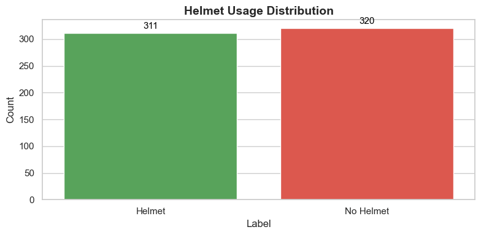

```python
# Apply mapping
mapped_labels = labels['Label'].map(text_labels)

# Set plot style
sns.set_theme(style="whitegrid")

# Create the countplot
plt.figure(figsize=(8, 4))
ax = sns.countplot(x=mapped_labels, palette=["#4CAF50", "#F44336"])  # Green for Helmet, Red for No helmet

# Add titles and labels
ax.set_title("Helmet Usage Distribution", fontsize=14, weight='bold')
ax.set_xlabel("Label", fontsize=12)
ax.set_ylabel("Count", fontsize=12)

# Annotate bars with counts
for p in ax.patches:
    ax.annotate(f'{int(p.get_height())}',
                (p.get_x() + p.get_width() / 2., p.get_height()),
                ha='center', va='center', fontsize=11, color='black', xytext=(0, 8),
                textcoords='offset points')

plt.tight_layout()
plt.show()
```

- Label Breakdown:
  - Helmet: 311 samples
  - No Helmet: 320 samples
- The dataset is nearly balanced, with a slight majority of individuals not wearing helmets.
- Minimal class imbalance suggests that standard classification models should perform reliably without requiring resampling techniques.

# **5 - Data Preprocessing**

## Converting images to grayscale

```python
# Converting the images from BGR to RGB using cvtColor function of OpenCV
images_grey = []
for i in range(len(images)):
  images_grey.append(cv2.cvtColor(images[i], cv2.COLOR_RGB2GRAY))

images_grey = np.array(images_grey)
```

[figure not shown]

```python
# Show a sample grey image
plt.imshow(images_grey[5], cmap='gray')
plt.axis('off')
plt.show()
```

[figure not shown]

```python
# Plot random grey images from the dataset
plot_images(images_grey,labels, cmap="gray")
```

The dataset was converted to grayscale. Images are shown in black and white.

## Splitting the dataset

```python
# Define the target variable
y = labels['Label'].values
```

```python
# Split the data into training, validation, and test sets with stratification
X_train, X_temp, y_train, y_temp = train_test_split(images, y, test_size=0.2, random_state=RS, stratify=y)
X_val, X_test, y_val, y_test = train_test_split(X_temp,y_temp , test_size=0.5, random_state=RS, stratify=y_temp)
```

```python
print("Training, Validation and Test set shapes:")
print("X_train Shape:", X_train.shape, "y_train Shape:", y_train.shape)
print("X_val Shape:", X_val.shape, "y_val Shape:",y_val.shape)
print("X_test Shape:", X_test.shape, "y_test Shape:",y_test.shape)
```

```
Training, Validation and Test set shapes:
X_train Shape: (504, 200, 200, 3) y_train Shape: (504,)
X_val Shape: (63, 200, 200, 3) y_val Shape: (63,)
X_test Shape: (64, 200, 200, 3) y_test Shape: (64,)
```

The dataset contains 631 RGB images of size (200, 200, 3), split into:

- Training: 504 samples (~80%)
- Validation: 63 samples (~10%)
- Test: 64 samples (~10%)

## Data Normalization

```python
# Normalizing the image pixels
X_train_normalized = X_train.astype('float32')/255.0
X_val_normalized = X_val.astype('float32')/255.0
X_test_normalized = X_test.astype('float32')/255.0
```

Given that image pixel intensities span from 0 to 255, we apply normalization by scaling each value—dividing by 255—to transform the data into a standardized range between 0 and 1.

# **6 - Model Building**

## Model Evaluation Criterion

The primary objective of the model is the accurate detection of individuals not wearing helmets. To ensure operational reliability, it is critical to minimize False Positive predictions, wherein the system erroneously classifies a helmeted individual as non-helmeted.

Consequently, model evaluation must prioritize the precision metric for the "No Helmet" class. This metric quantifies the proportion of true positive identifications (correctly identified non-helmet instances) against all instances the model predicted as positive (both true and false positives), thereby directly measuring the model's rate of erroneous alerts.

#### Utility Functions

```python
# defining a function to compute different metrics to check performance of a classification model built using statsmodels
def model_performance_classification(model, predictors, target):
    """
    Function to compute different metrics to check classification model performance

    model: classifier
    predictors: independent variables
    target: dependent variable
    """

    # checking which probabilities are greater than threshold
    pred = model.predict(predictors).reshape(-1)>0.5

    target = target.reshape(-1)


    acc = accuracy_score(target, pred)  # to compute Accuracy
    recall = recall_score(target, pred, average='weighted')  # to compute Recall
    precision = precision_score(target, pred, average='weighted')  # to compute Precision
    f1 = f1_score(target, pred, average='weighted')  # to compute F1-score

    # creating a dataframe of metrics
    df_perf = pd.DataFrame({"Accuracy": acc, "Recall": recall, "Precision": precision, "F1 Score": f1,},index=[0],)

    return df_perf
```

```python
# Function to plot the confusion matrix
def plot_confusion_matrix(model,predictors,target,ml=False, title="Confusion Matrix"):
    """
    Function to plot the confusion matrix

    model: classifier
    predictors: independent variables
    target: dependent variable
    ml: To specify if the model used is an sklearn ML model or not (True means ML model)
    """

    # checking which probabilities are greater than threshold
    pred = model.predict(predictors).reshape(-1)>0.5

    target = target.reshape(-1)

    # Plotting the Confusion Matrix using confusion matrix() function which is also predefined tensorflow module
    confusion_matrix = tf.math.confusion_matrix(target,pred)

    # Plot
    plt.figure(figsize=(8, 6))
    ax = sns.heatmap(confusion_matrix, annot=True, fmt="d", cmap="Blues", cbar=False, linewidths=0.5, square=True)

    # Axis labels
    ax.set_xlabel("Predicted Label")
    ax.set_ylabel("True Label")
    ax.set_title(title)

    # Annotate TP, FP, FN, TN below the numbers
    labels = np.array([["TN", "FP"], ["FN", "TP"]])
    for i in range(2):
        for j in range(2):
            ax.text(j + 0.5, i + 0.75, labels[i, j], ha='center', va='top', color='black', fontsize=10)

    plt.tight_layout()
    plt.show()
```

```python
# Function to plot training and validation accuracy and loss
def plot_accuracy_loss(history, title='Model Performance'):
    """
    Plots training and validation accuracy, loss, and precision over epochs.

    Parameters:
    ----------
    history : keras.callbacks.History
        Fitted model history object containing training metrics.
    title : str, optional
        Title for the overall figure (default is 'Model Performance').

    Displays:
    --------
    A matplotlib figure with three subplots:
        - Accuracy vs. Epoch
        - Loss vs. Epoch
        - Precision vs. Epoch
    """
    fig, axs = plt.subplots(1, 3, figsize=(18, 4))

    # Accuracy plot
    axs[0].plot(history.history['accuracy'], label='Train')
    axs[0].plot(history.history['val_accuracy'], label='Validation')
    axs[0].set_title('Model Accuracy')
    axs[0].set_xlabel('Epoch')
    axs[0].set_ylabel('Accuracy')
    axs[0].legend(loc='lower right')
    axs[0].grid(True)

    # Loss plot
    axs[1].plot(history.history['loss'], label='Train')
    axs[1].plot(history.history['val_loss'], label='Validation')
    axs[1].set_title('Model Loss')
    axs[1].set_xlabel('Epoch')
    axs[1].set_ylabel('Loss')
    axs[1].legend(loc='upper right')
    axs[1].grid(True)

     # Precision plot
    axs[2].plot(history.history['precision'], label='Train')
    axs[2].plot(history.history['val_precision'], label='Validation')
    axs[2].set_title('Model Precision')
    axs[2].set_xlabel('Epoch')
    axs[2].set_ylabel('Precision')
    axs[2].legend(loc='lower right')
    axs[2].grid(True)

    fig.suptitle(title)
    plt.tight_layout()
    plt.show()
```

```python
# Function to visualize random predictions
def visualize_random_predictions(model, X_val, X_val_normalized, y_val, text_labels, n=3, input_shape=(200, 200, 3)):
    """
    Displays random validation images with predicted and true labels.

    Parameters:
    ----------
    model : keras.Model
        Trained model used for prediction.
    X_val : np.ndarray
        Original validation images for display.
    X_val_normalized : np.ndarray
        Preprocessed validation images for model input.
    y_val : np.ndarray
        Ground truth labels (binary: 0 or 1).
    text_labels : list of str
        Text labels corresponding to class indices, e.g., ["Helmet", "No Helmet"].
    n : int, optional
        Number of random samples to visualize (default is 3).
    input_shape : tuple, optional
        Shape of input expected by the model (default is (200, 200, 3)).

    Displays:
    --------
    n matplotlib figures showing:
        - The original image
        - Predicted label (thresholded at 0.5)
        - True label
    """
    indices = np.random.choice(len(X_val), size=n, replace=False)

    for idx in indices:
        # Prepare image for prediction
        img_input = X_val_normalized[idx].reshape(1, *input_shape)
        pred = model.predict(img_input)
        pred_label = text_labels[int(pred[0] > 0.5)]  # Thresholding sigmoid output
        true_label = text_labels[y_val[idx]]

        # Display image
        plt.figure(figsize=(2.5, 2.5))
        plt.imshow(X_val[idx].squeeze(), cmap='gray' if input_shape[-1] == 1 else None)
        plt.axis('off')
        plt.title(f'Predicted: {pred_label}\nTrue: {true_label}', fontsize=10)
        plt.tight_layout()
        plt.show()
```

```python
# Function to plot random images from the dataset
def plot_aug_images(images, labels, datagen, rows=3, cols=3, cmap="viridis"):
    """
    Plots a grid of randomly augmented images using the provided ImageDataGenerator.

    Parameters:
    - images: numpy array of input images
    - labels: corresponding labels (can be ignored for visualization)
    - datagen: configured ImageDataGenerator instance
    - rows: number of rows in the plot grid (default: 3)
    - cols: number of columns in the plot grid (default: 4)
    - cmap: color map for displaying images (default: "viridis")
    """
    fig, axes = plt.subplots(rows, cols, figsize=(cols * 2.5, rows * 2.5))
    aug_iter = datagen.flow(images, labels, batch_size=1, shuffle=True)

    for i in range(rows * cols):
        batch = next(aug_iter)
        image = batch[0][0].astype('uint8')  # Extract the first image from the batch
        ax = axes[i // cols, i % cols]
        ax.imshow(image, cmap=cmap)
        ax.axis('off')

    plt.tight_layout()
    plt.show()
```

## Model 1: Simple Convolutional Neural Network (CNN)

```python
# Clearing backend session
backend.clear_session()
```

```python
# Building the CNN model
cnn_model = Sequential([
    Conv2D(32, (3, 3), activation='relu', input_shape=(200, 200, 3)),
    MaxPooling2D((2, 2)),
    Conv2D(64, (3, 3), activation='relu'),
    MaxPooling2D((2, 2)),
    Conv2D(128, (3, 3), activation='relu'),
    MaxPooling2D((2, 2)),

    Flatten(),
    Dense(128, activation='relu'),
    Dropout(0.5),
    Dense(64, activation='relu'),
    Dropout(0.5),
    Dense(1, activation='sigmoid')
])
```

```python
# Display the model summary
cnn_model.summary()
```

```
Model: "sequential"
```

```
┏━━━━━━━━━━━━━━━━━━━━━━━━━━━━━━━━━┳━━━━━━━━━━━━━━━━━━━━━━━━┳━━━━━━━━━━━━━━━┓
┃ Layer (type)                    ┃ Output Shape           ┃       Param # ┃
┡━━━━━━━━━━━━━━━━━━━━━━━━━━━━━━━━━╇━━━━━━━━━━━━━━━━━━━━━━━━╇━━━━━━━━━━━━━━━┩
│ conv2d (Conv2D)                 │ (None, 198, 198, 32)   │           896 │
├─────────────────────────────────┼────────────────────────┼───────────────┤
│ max_pooling2d (MaxPooling2D)    │ (None, 99, 99, 32)     │             0 │
├─────────────────────────────────┼────────────────────────┼───────────────┤
│ conv2d_1 (Conv2D)               │ (None, 97, 97, 64)     │        18,496 │
├─────────────────────────────────┼────────────────────────┼───────────────┤
│ max_pooling2d_1 (MaxPooling2D)  │ (None, 48, 48, 64)     │             0 │
├─────────────────────────────────┼────────────────────────┼───────────────┤
│ conv2d_2 (Conv2D)               │ (None, 46, 46, 128)    │        73,856 │
├─────────────────────────────────┼────────────────────────┼───────────────┤
│ max_pooling2d_2 (MaxPooling2D)  │ (None, 23, 23, 128)    │             0 │
├─────────────────────────────────┼────────────────────────┼───────────────┤
│ flatten (Flatten)               │ (None, 67712)          │             0 │
├─────────────────────────────────┼────────────────────────┼───────────────┤
│ dense (Dense)                   │ (None, 128)            │     8,667,264 │
├─────────────────────────────────┼────────────────────────┼───────────────┤
│ dropout (Dropout)               │ (None, 128)            │             0 │
├─────────────────────────────────┼────────────────────────┼───────────────┤
│ dense_1 (Dense)                 │ (None, 64)             │         8,256 │
├─────────────────────────────────┼────────────────────────┼───────────────┤
│ dropout_1 (Dropout)             │ (None, 64)             │             0 │
├─────────────────────────────────┼────────────────────────┼───────────────┤
│ dense_2 (Dense)                 │ (None, 1)              │            65 │
└─────────────────────────────────┴────────────────────────┴───────────────┘
```

```
 Total params: 8,768,833 (33.45 MB)
```

```
 Trainable params: 8,768,833 (33.45 MB)
```

```
 Non-trainable params: 0 (0.00 B)
```

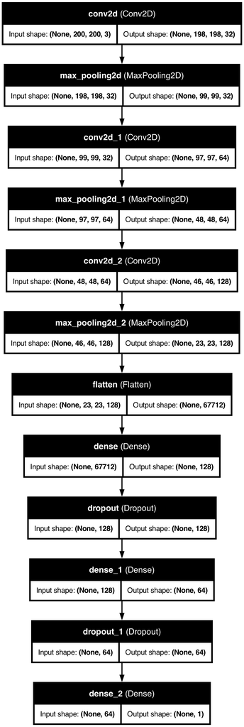

```python
# Visualize the model architecture
tf.keras.utils.plot_model(cnn_model, show_shapes=True, show_layer_names=True)
```

The proposed convolutional neural network (CNN) follows a sequential architecture. It comprises three convolutional blocks, each consisting of a Conv2D layer followed by MaxPooling2D, progressively increasing the number of filters from 32 to 128 to capture hierarchical spatial features. The convolutional layers employ small kernel sizes (3×3) and ReLU activations to extract localized patterns, while max pooling reduces spatial dimensions and mitigates overfitting.

The feature maps are flattened and passed through two fully connected layers (128 and 64 units, respectively), interleaved with dropout layers to enhance generalization. The final dense layer with a single sigmoid-activated neuron outputs the probability of the positive class.

The model contains approximately 8.77 million trainable parameters, with the majority concentrated in the dense layers.

```python
# Compiling the model
cnn_model.compile(optimizer='adam',
              loss='binary_crossentropy',
              metrics=['accuracy', 'precision'])
```

```python
# Training the model
history_cnn = cnn_model.fit(
    X_train_normalized, y_train,
    epochs=EPOCHS,
    batch_size=BATCH_SIZE,
    validation_data=(X_val_normalized, y_val),
    shuffle=True,
    verbose=2,
)
```

```
16/16 - 19s - 1s/step - accuracy: 0.7163 - loss: 0.4703 - precision: 0.6479 - val_accuracy: 0.9841 - val_loss: 0.0580 - val_precision: 1.0000
16/16 - 14s - 854ms/step - accuracy: 0.9563 - loss: 0.1437 - precision: 0.9414 - val_accuracy: 1.0000 - val_loss: 0.0086 - val_precision: 1.0000
16/16 - 14s - 870ms/step - accuracy: 0.9821 - loss: 0.0555 - precision: 0.9799 - val_accuracy: 1.0000 - val_loss: 0.0029 - val_precision: 1.0000
16/16 - 13s - 786ms/step - accuracy: 0.9960 - loss: 0.0207 - precision: 0.9960 - val_accuracy: 1.0000 - val_loss: 2.4800e-04 - val_precision: 1.0000
16/16 - 13s - 782ms/step - accuracy: 0.9802 - loss: 0.1141 - precision: 0.9798 - val_accuracy: 1.0000 - val_loss: 0.0100 - val_precision: 1.0000
16/16 - 14s - 850ms/step - accuracy: 0.9921 - loss: 0.0439 - precision: 0.9959 - val_accuracy: 1.0000 - val_loss: 0.0022 - val_precision: 1.0000
16/16 - 13s - 789ms/step - accuracy: 0.9960 - loss: 0.0234 - precision: 0.9960 - val_accuracy: 1.0000 - val_loss: 1.3377e-04 - val_precision: 1.0000
16/16 - 13s - 789ms/step - accuracy: 0.9960 - loss: 0.0146 - precision: 0.9960 - val_accuracy: 1.0000 - val_loss: 0.0019 - val_precision: 1.0000
16/16 - 12s - 754ms/step - accuracy: 0.9960 - loss: 0.0067 - precision: 0.9960 - val_accuracy: 1.0000 - val_loss: 3.4123e-06 - val_precision: 1.0000
16/16 - 12s - 747ms/step - accuracy: 1.0000 - loss: 0.0021 - precision: 1.0000 - val_accuracy: 1.0000 - val_loss: 2.9532e-05 - val_precision: 1.0000
16/16 - 12s - 772ms/step - accuracy: 1.0000 - loss: 5.9379e-04 - precision: 1.0000 - val_accuracy: 1.0000 - val_loss: 2.0922e-07 - val_precision: 1.0000
16/16 - 13s - 790ms/step - accuracy: 0.9960 - loss: 0.0242 - precision: 0.9960 - val_accuracy: 1.0000 - val_loss: 2.7005e-05 - val_precision: 1.0000
16/16 - 12s - 759ms/step - accuracy: 0.9960 - loss: 0.0127 - precision: 0.9960 - val_accuracy: 1.0000 - val_loss: 0.0062 - val_precision: 1.0000
16/16 - 12s - 750ms/step - accuracy: 0.9921 - loss: 0.0224 - precision: 1.0000 - val_accuracy: 1.0000 - val_loss: 0.0012 - val_precision: 1.0000
16/16 - 13s - 793ms/step - accuracy: 0.9980 - loss: 0.0060 - precision: 0.9960 - val_accuracy: 1.0000 - val_loss: 6.2978e-05 - val_precision: 1.0000
16/16 - 12s - 770ms/step - accuracy: 0.9980 - loss: 0.0027 - precision: 1.0000 - val_accuracy: 1.0000 - val_loss: 1.3622e-05 - val_precision: 1.0000
16/16 - 13s - 782ms/step - accuracy: 1.0000 - loss: 6.8958e-04 - precision: 1.0000 - val_accuracy: 1.0000 - val_loss: 5.8476e-06 - val_precision: 1.0000
16/16 - 13s - 783ms/step - accuracy: 0.9980 - loss: 0.0122 - precision: 1.0000 - val_accuracy: 1.0000 - val_loss: 3.2693e-06 - val_precision: 1.0000
16/16 - 13s - 824ms/step - accuracy: 1.0000 - loss: 0.0011 - precision: 1.0000 - val_accuracy: 1.0000 - val_loss: 2.1096e-06 - val_precision: 1.0000
16/16 - 12s - 765ms/step - accuracy: 1.0000 - loss: 7.4505e-04 - precision: 1.0000 - val_accuracy: 1.0000 - val_loss: 1.2695e-06 - val_precision: 1.0000
```

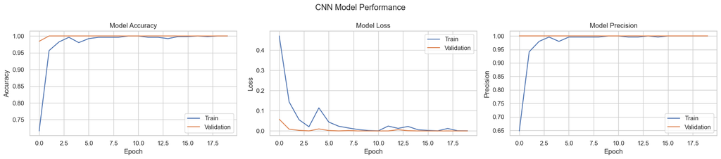

```python
# Plotting training accuracy and loss
plot_accuracy_loss(history_cnn, title='CNN Model Performance')
```

Model Loss - Train Loss drops sharply in the early epochs and then plateaus. Validation Loss stays low and stable throughout.

```python
# Model performance on the training set
model_1_train_perf = model_performance_classification(cnn_model, X_train_normalized, y_train)
print("Train performance metrics")
print(model_1_train_perf)
```

```
16/16 ━━━━━━━━━━━━━━━━━━━━ 3s 172ms/step
Train performance metrics
   Accuracy  Recall  Precision  F1 Score
0       1.0     1.0        1.0       1.0
```

```
16/16 ━━━━━━━━━━━━━━━━━━━━ 3s 173ms/step
```

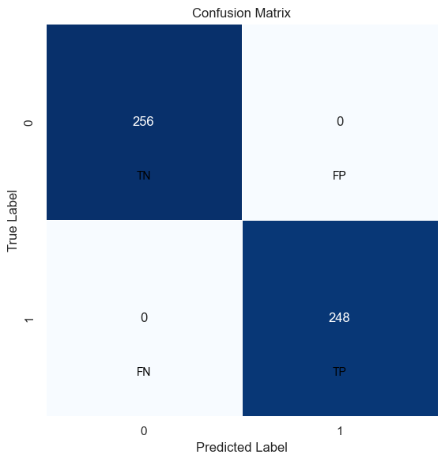

```python
# Plotting confusion matrix for training set
plot_confusion_matrix(cnn_model, X_train_normalized, y_train)
```

On the training dataset, the model achieved perfect classification performance. This is confirmed by the confusion matrix, which shows 256 true negatives and 248 true positives, with zero false positives and zero false negatives. In other words, the model correctly identified every instance of both the negative and positive classes without any misclassification.

```python
# Model performance on the validation set
model_1_val_perf = model_performance_classification(cnn_model, X_val_normalized, y_val)
print("Validation performance metrics")
print(model_1_val_perf)
```

```
2/2 ━━━━━━━━━━━━━━━━━━━━ 0s 178ms/step
Validation performance metrics
   Accuracy  Recall  Precision  F1 Score
0       1.0     1.0        1.0       1.0
```

```
2/2 ━━━━━━━━━━━━━━━━━━━━ 0s 179ms/step
```

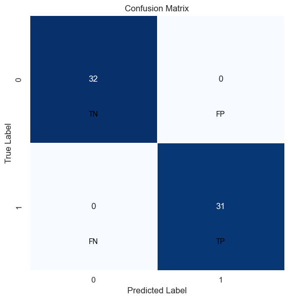

```python
# Plotting confusion matrix for validation set
plot_confusion_matrix(cnn_model, X_val_normalized, y_val)
```

On the validation dataset, the model maintained perfect classification performance. The confusion matrix reports 32 true negatives and 31 true positives, with zero false positives and zero false negatives. This indicates that the model accurately predicted every instance of both classes without error. Such results suggest strong generalization from the training data to unseen samples.

### Vizualizing the predictions

```
1/1 ━━━━━━━━━━━━━━━━━━━━ 0s 39ms/step
```

[figure not shown]

```
1/1 ━━━━━━━━━━━━━━━━━━━━ 0s 34ms/step
```

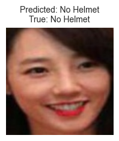

```
1/1 ━━━━━━━━━━━━━━━━━━━━ 0s 32ms/step
```

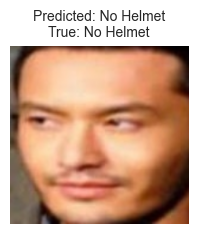

```python
# Visualizing random predictions
visualize_random_predictions(cnn_model, X_val, X_val_normalized, y_val, text_labels, n=3, input_shape=(200, 200, 3))
```

The samples illustrate randomly selected predictions from the validation dataset. Each instance was classified accurately, demonstrating the model’s consistent performance and its capacity to generalize effectively to unseen data.

## Model 2: (VGG-16 (Base))

For the second model architecture, we adopt a Transfer Learning approach, leveraging the representational power of pre-trained convolutional neural networks. Specifically, we utilize the VGG16 model as the foundational feature extractor. In our implementation, the convolutional base of VGG16 is imported without its top classification layers, thereby preserving only the convolutional blocks responsible for feature extraction. This base is then extended by appending a Flatten layer. Subsequently, we incorporate a fully connected output layer with a Sigmoid activation function.

```python
# VGG16 Model
vgg_model = VGG16(weights='imagenet',include_top=False,input_shape=(200,200,3))
vgg_model.summary()
```

```
Model: "vgg16"
```

```
┏━━━━━━━━━━━━━━━━━━━━━━━━━━━━━━━━━┳━━━━━━━━━━━━━━━━━━━━━━━━┳━━━━━━━━━━━━━━━┓
┃ Layer (type)                    ┃ Output Shape           ┃       Param # ┃
┡━━━━━━━━━━━━━━━━━━━━━━━━━━━━━━━━━╇━━━━━━━━━━━━━━━━━━━━━━━━╇━━━━━━━━━━━━━━━┩
│ input_layer_1 (InputLayer)      │ (None, 200, 200, 3)    │             0 │
├─────────────────────────────────┼────────────────────────┼───────────────┤
│ block1_conv1 (Conv2D)           │ (None, 200, 200, 64)   │         1,792 │
├─────────────────────────────────┼────────────────────────┼───────────────┤
│ block1_conv2 (Conv2D)           │ (None, 200, 200, 64)   │        36,928 │
├─────────────────────────────────┼────────────────────────┼───────────────┤
│ block1_pool (MaxPooling2D)      │ (None, 100, 100, 64)   │             0 │
├─────────────────────────────────┼────────────────────────┼───────────────┤
│ block2_conv1 (Conv2D)           │ (None, 100, 100, 128)  │        73,856 │
├─────────────────────────────────┼────────────────────────┼───────────────┤
│ block2_conv2 (Conv2D)           │ (None, 100, 100, 128)  │       147,584 │
├─────────────────────────────────┼────────────────────────┼───────────────┤
│ block2_pool (MaxPooling2D)      │ (None, 50, 50, 128)    │             0 │
├─────────────────────────────────┼────────────────────────┼───────────────┤
│ block3_conv1 (Conv2D)           │ (None, 50, 50, 256)    │       295,168 │
├─────────────────────────────────┼────────────────────────┼───────────────┤
│ block3_conv2 (Conv2D)           │ (None, 50, 50, 256)    │       590,080 │
├─────────────────────────────────┼────────────────────────┼───────────────┤
│ block3_conv3 (Conv2D)           │ (None, 50, 50, 256)    │       590,080 │
├─────────────────────────────────┼────────────────────────┼───────────────┤
│ block3_pool (MaxPooling2D)      │ (None, 25, 25, 256)    │             0 │
├─────────────────────────────────┼────────────────────────┼───────────────┤
│ block4_conv1 (Conv2D)           │ (None, 25, 25, 512)    │     1,180,160 │
├─────────────────────────────────┼────────────────────────┼───────────────┤
│ block4_conv2 (Conv2D)           │ (None, 25, 25, 512)    │     2,359,808 │
├─────────────────────────────────┼────────────────────────┼───────────────┤
│ block4_conv3 (Conv2D)           │ (None, 25, 25, 512)    │     2,359,808 │
├─────────────────────────────────┼────────────────────────┼───────────────┤
│ block4_pool (MaxPooling2D)      │ (None, 12, 12, 512)    │             0 │
├─────────────────────────────────┼────────────────────────┼───────────────┤
│ block5_conv1 (Conv2D)           │ (None, 12, 12, 512)    │     2,359,808 │
├─────────────────────────────────┼────────────────────────┼───────────────┤
│ block5_conv2 (Conv2D)           │ (None, 12, 12, 512)    │     2,359,808 │
├─────────────────────────────────┼────────────────────────┼───────────────┤
│ block5_conv3 (Conv2D)           │ (None, 12, 12, 512)    │     2,359,808 │
├─────────────────────────────────┼────────────────────────┼───────────────┤
│ block5_pool (MaxPooling2D)      │ (None, 6, 6, 512)      │             0 │
└─────────────────────────────────┴────────────────────────┴───────────────┘
```

```
 Total params: 14,714,688 (56.13 MB)
```

```
 Trainable params: 14,714,688 (56.13 MB)
```

```
 Non-trainable params: 0 (0.00 B)
```

The VGG16 model consists of five convolutional blocks, each followed by max-pooling layers that progressively reduce spatial dimensions while increasing feature depth. Starting with an input of 200×200×3, the network extracts hierarchical features through 13 convolutional layers, culminating in a final output of shape 6×6×512. With over 14.7 million trainable parameters, this architecture serves as a powerful backbone for transfer learning, enabling efficient adaptation to new image classification tasks.

```python
# Making all the layers of the VGG model non-trainable.
for layer in vgg_model.layers:
    layer.trainable = False
```

The second model consists of the VGG16 base, a flatten layer and output layer with Sigmoid activation.

```python
# Model 2 Architecture
vgg16_base_model = Sequential([
    vgg_model,
    Flatten(),
    Dense(1, activation='sigmoid'),
])
```

```python
# Display the model summary
vgg16_base_model.summary()
```

```
Model: "sequential_1"
```

```
┏━━━━━━━━━━━━━━━━━━━━━━━━━━━━━━━━━┳━━━━━━━━━━━━━━━━━━━━━━━━┳━━━━━━━━━━━━━━━┓
┃ Layer (type)                    ┃ Output Shape           ┃       Param # ┃
┡━━━━━━━━━━━━━━━━━━━━━━━━━━━━━━━━━╇━━━━━━━━━━━━━━━━━━━━━━━━╇━━━━━━━━━━━━━━━┩
│ vgg16 (Functional)              │ (None, 6, 6, 512)      │    14,714,688 │
├─────────────────────────────────┼────────────────────────┼───────────────┤
│ flatten_1 (Flatten)             │ (None, 18432)          │             0 │
├─────────────────────────────────┼────────────────────────┼───────────────┤
│ dense_3 (Dense)                 │ (None, 1)              │        18,433 │
└─────────────────────────────────┴────────────────────────┴───────────────┘
```

```
 Total params: 14,733,121 (56.20 MB)
```

```
 Trainable params: 18,433 (72.00 KB)
```

```
 Non-trainable params: 14,714,688 (56.13 MB)
```

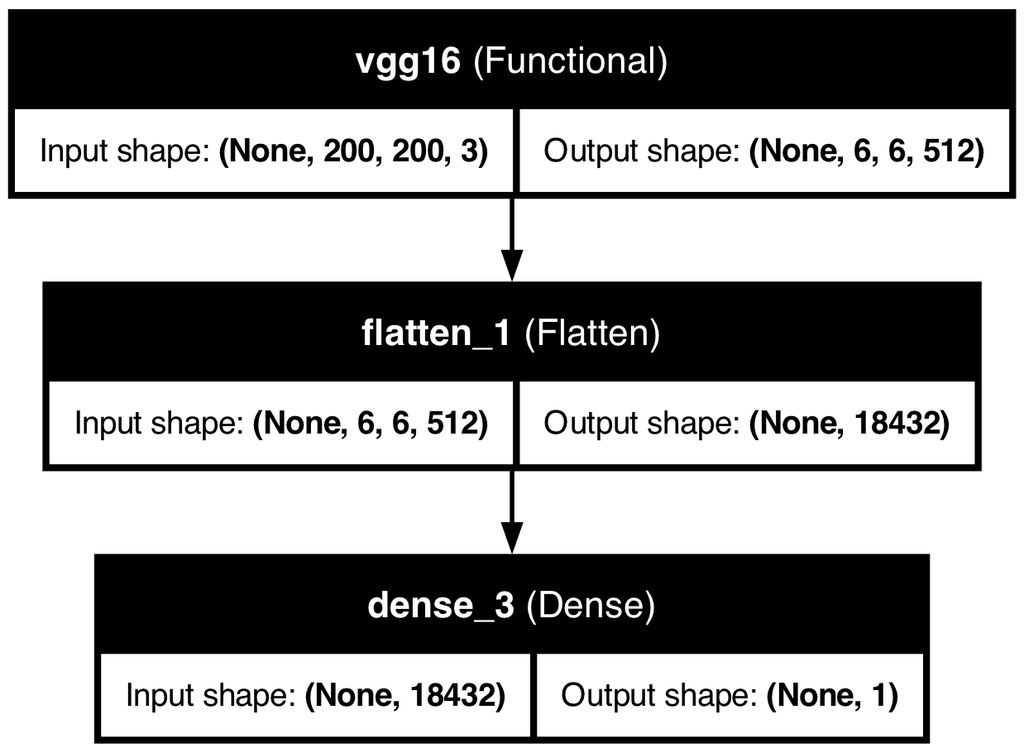

```python
tf.keras.utils.plot_model(vgg16_base_model, show_shapes=True, show_layer_names=True)
```

This model architecture builds upon the pre-trained VGG16 network, which serves as a fixed feature extractor with over 14.7 million non-trainable parameters. The output from VGG16—a 6×6×512 feature map—is flattened into a 1D vector of 18,432 elements, which is then passed to a single Dense layer with one output unit. This final layer, containing 18,433 trainable parameters, enables binary classification. By freezing the convolutional base and training only the output layer, the model efficiently adapts high-level visual features to a new task while minimizing overfitting and computational cost.

```python
# Compiling the model
vgg16_base_model.compile(optimizer='adam',
              loss='binary_crossentropy',
              metrics=['accuracy', 'precision'])
```

```python
# Training the model
history_vgg16_base = vgg16_base_model.fit(
    X_train_normalized, y_train,
    epochs=EPOCHS,
    batch_size=BATCH_SIZE,
    validation_data=(X_val_normalized, y_val),
    shuffle=True,
    verbose=2,
    steps_per_epoch=X_train_normalized.shape[0] // BATCH_SIZE
)
```

```
15/15 - 29s - 2s/step - accuracy: 0.8667 - loss: 0.3036 - precision: 0.9087 - val_accuracy: 1.0000 - val_loss: 0.0287 - val_precision: 1.0000
15/15 - 4s - 294ms/step - accuracy: 1.0000 - loss: 0.0275 - precision: 1.0000 - val_accuracy: 1.0000 - val_loss: 0.0296 - val_precision: 1.0000
15/15 - 27s - 2s/step - accuracy: 1.0000 - loss: 0.0165 - precision: 1.0000 - val_accuracy: 1.0000 - val_loss: 0.0073 - val_precision: 1.0000
15/15 - 4s - 290ms/step - accuracy: 1.0000 - loss: 0.0063 - precision: 1.0000 - val_accuracy: 1.0000 - val_loss: 0.0066 - val_precision: 1.0000
15/15 - 26s - 2s/step - accuracy: 1.0000 - loss: 0.0050 - precision: 1.0000 - val_accuracy: 1.0000 - val_loss: 0.0039 - val_precision: 1.0000
15/15 - 4s - 287ms/step - accuracy: 1.0000 - loss: 0.0026 - precision: 1.0000 - val_accuracy: 1.0000 - val_loss: 0.0038 - val_precision: 1.0000
15/15 - 26s - 2s/step - accuracy: 1.0000 - loss: 0.0036 - precision: 1.0000 - val_accuracy: 1.0000 - val_loss: 0.0034 - val_precision: 1.0000
15/15 - 4s - 290ms/step - accuracy: 1.0000 - loss: 0.0023 - precision: 1.0000 - val_accuracy: 1.0000 - val_loss: 0.0034 - val_precision: 1.0000
15/15 - 26s - 2s/step - accuracy: 1.0000 - loss: 0.0029 - precision: 1.0000 - val_accuracy: 1.0000 - val_loss: 0.0033 - val_precision: 1.0000
15/15 - 4s - 295ms/step - accuracy: 1.0000 - loss: 0.0023 - precision: 1.0000 - val_accuracy: 1.0000 - val_loss: 0.0033 - val_precision: 1.0000
15/15 - 26s - 2s/step - accuracy: 1.0000 - loss: 0.0025 - precision: 1.0000 - val_accuracy: 1.0000 - val_loss: 0.0031 - val_precision: 1.0000
15/15 - 4s - 283ms/step - accuracy: 1.0000 - loss: 0.0021 - precision: 1.0000 - val_accuracy: 1.0000 - val_loss: 0.0030 - val_precision: 1.0000
15/15 - 26s - 2s/step - accuracy: 1.0000 - loss: 0.0023 - precision: 1.0000 - val_accuracy: 1.0000 - val_loss: 0.0028 - val_precision: 1.0000
15/15 - 4s - 285ms/step - accuracy: 1.0000 - loss: 0.0018 - precision: 1.0000 - val_accuracy: 1.0000 - val_loss: 0.0028 - val_precision: 1.0000
15/15 - 26s - 2s/step - accuracy: 1.0000 - loss: 0.0020 - precision: 1.0000 - val_accuracy: 1.0000 - val_loss: 0.0026 - val_precision: 1.0000
15/15 - 4s - 286ms/step - accuracy: 1.0000 - loss: 0.0016 - precision: 1.0000 - val_accuracy: 1.0000 - val_loss: 0.0026 - val_precision: 1.0000
15/15 - 26s - 2s/step - accuracy: 1.0000 - loss: 0.0018 - precision: 1.0000 - val_accuracy: 1.0000 - val_loss: 0.0025 - val_precision: 1.0000
15/15 - 4s - 282ms/step - accuracy: 1.0000 - loss: 0.0015 - precision: 1.0000 - val_accuracy: 1.0000 - val_loss: 0.0025 - val_precision: 1.0000
15/15 - 26s - 2s/step - accuracy: 1.0000 - loss: 0.0017 - precision: 1.0000 - val_accuracy: 1.0000 - val_loss: 0.0023 - val_precision: 1.0000
15/15 - 4s - 285ms/step - accuracy: 1.0000 - loss: 0.0014 - precision: 1.0000 - val_accuracy: 1.0000 - val_loss: 0.0023 - val_precision: 1.0000
```

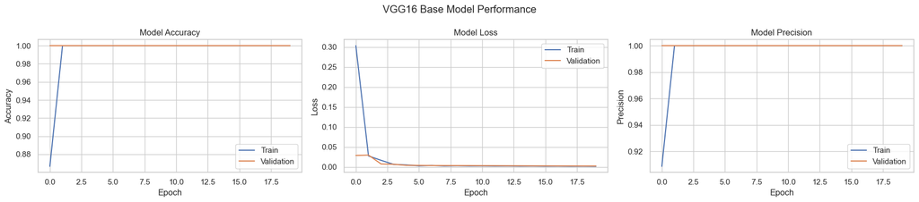

```python
# Plotting training accuracy and loss
plot_accuracy_loss(history_vgg16_base, title='VGG16 Base Model Performance')
```

```python
# Model performance on the training set
model_2_train_perf = model_performance_classification(vgg16_base_model, X_train_normalized, y_train)
print("Train performance metrics")
print(model_2_train_perf)
```

```
16/16 ━━━━━━━━━━━━━━━━━━━━ 26s 2s/step
Train performance metrics
   Accuracy  Recall  Precision  F1 Score
0       1.0     1.0        1.0       1.0
```

```
16/16 ━━━━━━━━━━━━━━━━━━━━ 29s 2s/step
```

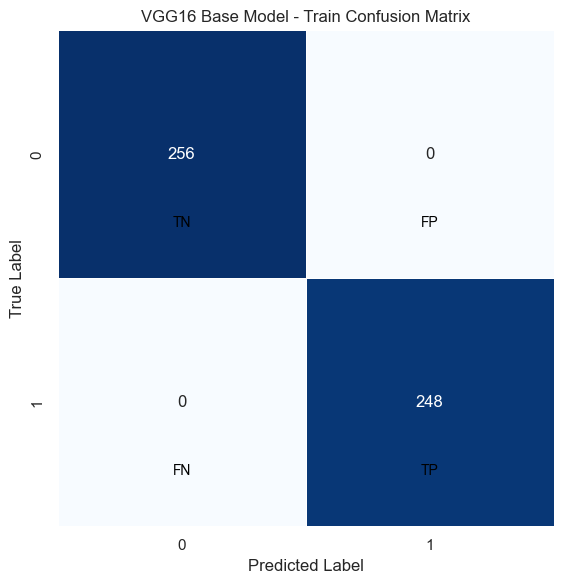

```python
# Plotting confusion matrix for training set
plot_confusion_matrix(vgg16_base_model, X_train_normalized, y_train, title="VGG16 Base Model - Train Confusion Matrix")
```

The confusion matrix shows that the VGG16 base model achieved perfect classification on the training set, with all 248 positive and 256 negative samples correctly identified—resulting in zero false positives and zero false negatives.

```python
# Model performance on the validation set
model_2_val_perf = model_performance_classification(vgg16_base_model, X_val_normalized, y_val)
print("Validation performance metrics")
print(model_2_val_perf)
```

```
2/2 ━━━━━━━━━━━━━━━━━━━━ 3s 2s/step
Validation performance metrics
   Accuracy  Recall  Precision  F1 Score
0       1.0     1.0        1.0       1.0
```

```
2/2 ━━━━━━━━━━━━━━━━━━━━ 3s 2s/step
```

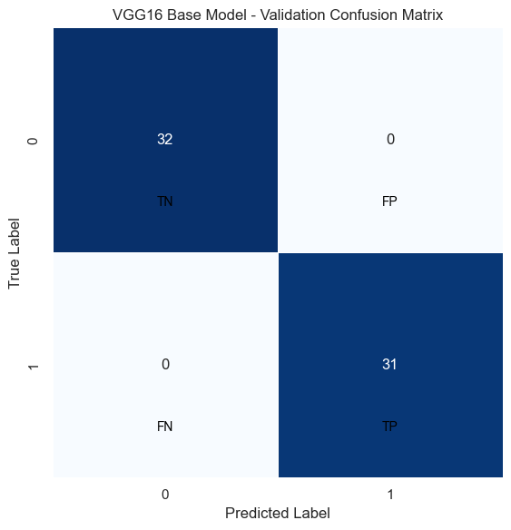

```python
# Plotting confusion matrix for validation set
plot_confusion_matrix(vgg16_base_model, X_val_normalized, y_val, title="VGG16 Base Model - Validation Confusion Matrix")
```

The confusion matrix for the validation set shows that the VGG16 base model achieved flawless classification performance, correctly identifying all 31 positive and 32 negative samples with zero false positives and zero false negatives. This results in 100% accuracy, precision, recall, and specificity on the validation data.

### Visualizing the prediction:

```
1/1 ━━━━━━━━━━━━━━━━━━━━ 0s 93ms/step
```

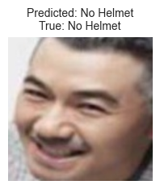

```
1/1 ━━━━━━━━━━━━━━━━━━━━ 0s 86ms/step
```

[figure not shown]

```
1/1 ━━━━━━━━━━━━━━━━━━━━ 0s 73ms/step
```

[figure not shown]

```python
# Visualizing random predictions
visualize_random_predictions(vgg16_base_model, X_val, X_val_normalized, y_val, text_labels, n=3, input_shape=(200, 200, 3))
```

The samples illustrate randomly selected predictions from the validation dataset. Each instance was classified accurately, demonstrating the model’s consistent performance and its capacity to generalize effectively to unseen data.

## Model 3: (VGG-16 (Base + FFNN))

This third model architecture extends the pre-trained VGG16 base with a fully connected feedforward neural network (FFNN). After extracting high-level features via the frozen VGG16 convolutional layers, the output is flattened into a one-dimensional vector and passed through two Dense layers with 256 and 128 units respectively, both using ReLU activation to introduce non-linearity. To mitigate overfitting, each Dense layer is followed by a Dropout layer with a 50% rate. The final output layer consists of a single neuron with sigmoid activation, producing a probability score for binary decision-making. This configuration balances the representational power of VGG16 with the flexibility of trainable dense layers, allowing the model to adapt to the specific classification task while maintaining generalization.

```python
# Model 3 Architecture
vgg_ffnn = Sequential([
    vgg_model,
    Flatten(),
    Dense(256, activation='relu'),
    Dropout(0.5),
    Dense(128, activation='relu'),
    Dropout(0.5),
    Dense(1, activation='sigmoid')
])
vgg_ffnn.summary()
```

```
Model: "sequential_2"
```

```
┏━━━━━━━━━━━━━━━━━━━━━━━━━━━━━━━━━┳━━━━━━━━━━━━━━━━━━━━━━━━┳━━━━━━━━━━━━━━━┓
┃ Layer (type)                    ┃ Output Shape           ┃       Param # ┃
┡━━━━━━━━━━━━━━━━━━━━━━━━━━━━━━━━━╇━━━━━━━━━━━━━━━━━━━━━━━━╇━━━━━━━━━━━━━━━┩
│ vgg16 (Functional)              │ (None, 6, 6, 512)      │    14,714,688 │
├─────────────────────────────────┼────────────────────────┼───────────────┤
│ flatten_2 (Flatten)             │ (None, 18432)          │             0 │
├─────────────────────────────────┼────────────────────────┼───────────────┤
│ dense_4 (Dense)                 │ (None, 256)            │     4,718,848 │
├─────────────────────────────────┼────────────────────────┼───────────────┤
│ dropout_2 (Dropout)             │ (None, 256)            │             0 │
├─────────────────────────────────┼────────────────────────┼───────────────┤
│ dense_5 (Dense)                 │ (None, 128)            │        32,896 │
├─────────────────────────────────┼────────────────────────┼───────────────┤
│ dropout_3 (Dropout)             │ (None, 128)            │             0 │
├─────────────────────────────────┼────────────────────────┼───────────────┤
│ dense_6 (Dense)                 │ (None, 1)              │           129 │
└─────────────────────────────────┴────────────────────────┴───────────────┘
```

```
 Total params: 19,466,561 (74.26 MB)
```

```
 Trainable params: 4,751,873 (18.13 MB)
```

```
 Non-trainable params: 14,714,688 (56.13 MB)
```

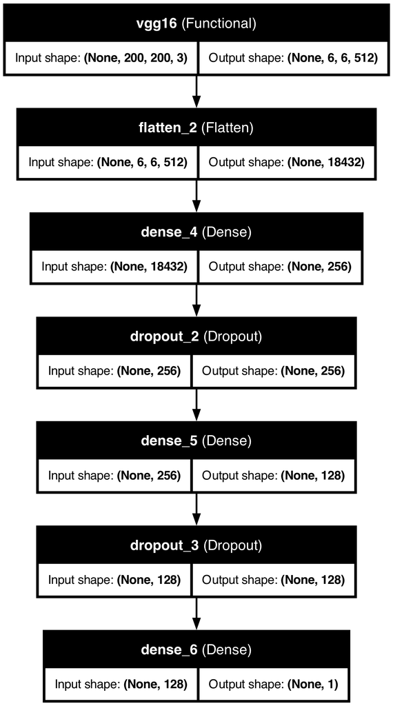

```python
tf.keras.utils.plot_model(vgg_ffnn, show_shapes=True, show_layer_names=True)
```

The VGG16 base contributes over 14.7 million non-trainable parameters, outputting a feature map of shape (6, 6, 512). This is flattened into a 1D vector of 18,432 elements, which feeds into two fully connected layers: the first with 256 units (4.7M parameters) and the second with 128 units (32.9K parameters), both using ReLU activation and followed by 50% dropout for regularization. The final Dense layer has a single sigmoid-activated neuron for binary classification. In total, the model comprises approximately 19.5 million parameters, of which 4.75 million are trainable—allowing the classifier to adapt while preserving the representational power of the frozen VGG16 backbone.

```python
# Compiling the model
vgg_ffnn.compile(optimizer='adam',
              loss='binary_crossentropy',
              metrics=['accuracy', 'precision'])
```

```python
# Training the model
history_vgg_ffnn = vgg_ffnn.fit(
    X_train_normalized, y_train,
    epochs=EPOCHS,
    batch_size=BATCH_SIZE,
    validation_data=(X_val_normalized, y_val),
    shuffle=True,
    verbose=2,
    steps_per_epoch=X_train_normalized.shape[0] // BATCH_SIZE,
)
```

```
15/15 - 31s - 2s/step - accuracy: 0.8583 - loss: 0.3973 - precision: 0.8705 - val_accuracy: 1.0000 - val_loss: 3.7824e-04 - val_precision: 1.0000
15/15 - 5s - 300ms/step - accuracy: 1.0000 - loss: 0.0041 - precision: 1.0000 - val_accuracy: 1.0000 - val_loss: 0.0010 - val_precision: 1.0000
15/15 - 27s - 2s/step - accuracy: 0.9854 - loss: 0.0477 - precision: 0.9749 - val_accuracy: 1.0000 - val_loss: 1.3059e-04 - val_precision: 1.0000
15/15 - 4s - 293ms/step - accuracy: 0.9583 - loss: 0.1614 - precision: 1.0000 - val_accuracy: 1.0000 - val_loss: 5.9560e-05 - val_precision: 1.0000
15/15 - 27s - 2s/step - accuracy: 0.9979 - loss: 0.0104 - precision: 0.9957 - val_accuracy: 1.0000 - val_loss: 8.9951e-07 - val_precision: 1.0000
15/15 - 4s - 298ms/step - accuracy: 1.0000 - loss: 0.0077 - precision: 1.0000 - val_accuracy: 1.0000 - val_loss: 9.8354e-07 - val_precision: 1.0000
15/15 - 28s - 2s/step - accuracy: 0.9958 - loss: 0.0074 - precision: 1.0000 - val_accuracy: 1.0000 - val_loss: 4.0597e-07 - val_precision: 1.0000
15/15 - 5s - 302ms/step - accuracy: 1.0000 - loss: 1.2372e-06 - precision: 1.0000 - val_accuracy: 1.0000 - val_loss: 4.0012e-07 - val_precision: 1.0000
15/15 - 27s - 2s/step - accuracy: 0.9979 - loss: 0.0137 - precision: 0.9957 - val_accuracy: 1.0000 - val_loss: 1.2201e-07 - val_precision: 1.0000
15/15 - 4s - 296ms/step - accuracy: 1.0000 - loss: 6.3985e-08 - precision: 1.0000 - val_accuracy: 1.0000 - val_loss: 9.4895e-08 - val_precision: 1.0000
15/15 - 27s - 2s/step - accuracy: 0.9979 - loss: 0.0022 - precision: 1.0000 - val_accuracy: 1.0000 - val_loss: 3.1366e-07 - val_precision: 1.0000
15/15 - 4s - 300ms/step - accuracy: 1.0000 - loss: 6.9209e-05 - precision: 1.0000 - val_accuracy: 1.0000 - val_loss: 2.9204e-07 - val_precision: 1.0000
15/15 - 27s - 2s/step - accuracy: 1.0000 - loss: 5.9478e-04 - precision: 1.0000 - val_accuracy: 1.0000 - val_loss: 1.7495e-07 - val_precision: 1.0000
15/15 - 5s - 300ms/step - accuracy: 1.0000 - loss: 1.1276e-05 - precision: 1.0000 - val_accuracy: 1.0000 - val_loss: 1.6644e-07 - val_precision: 1.0000
15/15 - 28s - 2s/step - accuracy: 1.0000 - loss: 3.5589e-04 - precision: 1.0000 - val_accuracy: 1.0000 - val_loss: 1.0156e-07 - val_precision: 1.0000
15/15 - 4s - 294ms/step - accuracy: 1.0000 - loss: 6.4765e-05 - precision: 1.0000 - val_accuracy: 1.0000 - val_loss: 9.9964e-08 - val_precision: 1.0000
15/15 - 27s - 2s/step - accuracy: 0.9979 - loss: 0.0061 - precision: 0.9957 - val_accuracy: 1.0000 - val_loss: 2.7874e-06 - val_precision: 1.0000
15/15 - 4s - 294ms/step - accuracy: 1.0000 - loss: 3.1654e-06 - precision: 1.0000 - val_accuracy: 1.0000 - val_loss: 2.9243e-06 - val_precision: 1.0000
15/15 - 27s - 2s/step - accuracy: 1.0000 - loss: 0.0012 - precision: 1.0000 - val_accuracy: 1.0000 - val_loss: 1.9890e-07 - val_precision: 1.0000
15/15 - 5s - 301ms/step - accuracy: 1.0000 - loss: 0.0023 - precision: 1.0000 - val_accuracy: 1.0000 - val_loss: 1.8011e-07 - val_precision: 1.0000
```

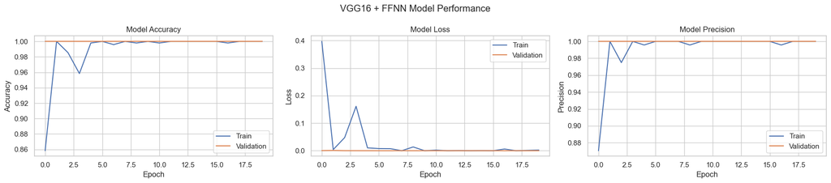

```python
# Plotting training accuracy and loss
plot_accuracy_loss(history_vgg_ffnn, title='VGG16 + FFNN Model Performance')
```

```python
# Model performance on the training set
model_vgg_ffnn_train_perf = model_performance_classification(vgg_ffnn, X_train_normalized, y_train)
print("Train performance metrics")
print(model_vgg_ffnn_train_perf)
```

```
16/16 ━━━━━━━━━━━━━━━━━━━━ 27s 2s/step
Train performance metrics
   Accuracy  Recall  Precision  F1 Score
0       1.0     1.0        1.0       1.0
```

```
16/16 ━━━━━━━━━━━━━━━━━━━━ 26s 2s/step
```

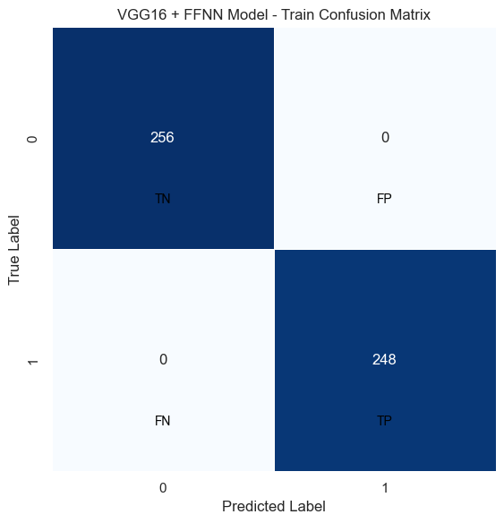

```python
# Plotting confusion matrix for training set
plot_confusion_matrix(vgg_ffnn, X_train_normalized, y_train, title="VGG16 + FFNN Model - Train Confusion Matrix")
```

The confusion matrix for the VGG16 + FFNN model on the training data shows perfect classification performance. All 256 negative samples were correctly predicted as class 0 (true negatives), and all 248 positive samples were correctly predicted as class 1 (true positives). There were zero false positives and zero false negatives, resulting in 100% accuracy, precision, and recall.

```python
# Model performance on the validation set
model_vgg_ffnn_val_perf = model_performance_classification(vgg_ffnn, X_val_normalized, y_val)
print("Validation performance metrics")
print(model_vgg_ffnn_val_perf)
```

```
2/2 ━━━━━━━━━━━━━━━━━━━━ 3s 2s/step
Validation performance metrics
   Accuracy  Recall  Precision  F1 Score
0       1.0     1.0        1.0       1.0
```

```
2/2 ━━━━━━━━━━━━━━━━━━━━ 3s 2s/step
```

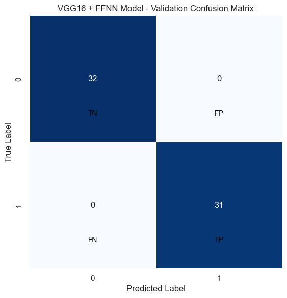

```python
# Plotting confusion matrix for validation set
plot_confusion_matrix(vgg_ffnn, X_val_normalized, y_val, title="VGG16 + FFNN Model - Validation Confusion Matrix")
```

The validation confusion matrix for the VGG16 + FFNN model reveals flawless classification performance, with all 32 negative samples correctly identified as class 0 and all 31 positive samples accurately predicted as class 1—resulting in zero false positives and zero false negatives.

#### Visualizing the predictions

```
1/1 ━━━━━━━━━━━━━━━━━━━━ 0s 88ms/step
```

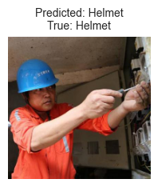

```
1/1 ━━━━━━━━━━━━━━━━━━━━ 0s 77ms/step
```

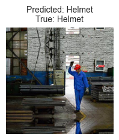

```
1/1 ━━━━━━━━━━━━━━━━━━━━ 0s 79ms/step
```

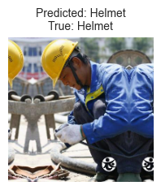

```python
# Visualizing random predictions
visualize_random_predictions(vgg_ffnn, X_val, X_val_normalized, y_val, text_labels, n=3, input_shape=(200, 200, 3))
```

The samples illustrate randomly selected predictions from the validation dataset. Each instance was classified accurately, demonstrating the model’s consistent performance and its capacity to generalize effectively to unseen data.

## Model 4: (VGG-16 (Base + FFNN + Data Augmentation)

Model 4 builds directly upon the architecture of Model 3, which combines a pre-trained VGG16 base with a fully connected feedforward neural network for binary classification. The key enhancement in this iteration is the integration of data augmentation during training, implemented via the ImageDataGenerator class. This augmentation pipeline introduces controlled variability to the input images through random rotations (up to 20 degrees), horizontal and vertical shifts (up to 20%), shearing, zooming, and flipping along both axes. These transformations help simulate real-world distortions and improve the model’s ability to generalize by exposing it to a broader range of input conditions. By enriching the training data without increasing dataset size, Model 4 aims to reduce overfitting and enhance robustness, especially when working with limited or homogeneous image samples.

```python
# Data Augmentation
train_data_gen = ImageDataGenerator(
    rotation_range=20,
    width_shift_range=0.2,
    height_shift_range=0.2,
    shear_range=0.2,
    zoom_range=0.2,
    horizontal_flip=True,
    vertical_flip=True,
)
```

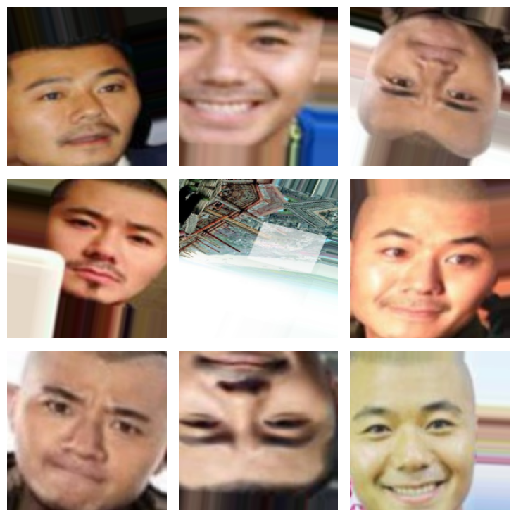

```python
# Plot augmented images
plot_aug_images(X_train, y_train, train_data_gen)
```

Here are some examples of the augmented images.

```python
# Model 4 Architecture with Data Augmentation
vgg_data_aug = Sequential([
    vgg_model,
    Flatten(),
    Dense(256, activation='relu'),
    Dropout(0.5),
    Dense(128, activation='relu'),
    Dropout(0.5),
    Dense(1, activation='sigmoid')
])
vgg_data_aug.summary()
```

```
Model: "sequential_3"
```

```
┏━━━━━━━━━━━━━━━━━━━━━━━━━━━━━━━━━┳━━━━━━━━━━━━━━━━━━━━━━━━┳━━━━━━━━━━━━━━━┓
┃ Layer (type)                    ┃ Output Shape           ┃       Param # ┃
┡━━━━━━━━━━━━━━━━━━━━━━━━━━━━━━━━━╇━━━━━━━━━━━━━━━━━━━━━━━━╇━━━━━━━━━━━━━━━┩
│ vgg16 (Functional)              │ (None, 6, 6, 512)      │    14,714,688 │
├─────────────────────────────────┼────────────────────────┼───────────────┤
│ flatten_3 (Flatten)             │ (None, 18432)          │             0 │
├─────────────────────────────────┼────────────────────────┼───────────────┤
│ dense_7 (Dense)                 │ (None, 256)            │     4,718,848 │
├─────────────────────────────────┼────────────────────────┼───────────────┤
│ dropout_4 (Dropout)             │ (None, 256)            │             0 │
├─────────────────────────────────┼────────────────────────┼───────────────┤
│ dense_8 (Dense)                 │ (None, 128)            │        32,896 │
├─────────────────────────────────┼────────────────────────┼───────────────┤
│ dropout_5 (Dropout)             │ (None, 128)            │             0 │
├─────────────────────────────────┼────────────────────────┼───────────────┤
│ dense_9 (Dense)                 │ (None, 1)              │           129 │
└─────────────────────────────────┴────────────────────────┴───────────────┘
```

```
 Total params: 19,466,561 (74.26 MB)
```

```
 Trainable params: 4,751,873 (18.13 MB)
```

```
 Non-trainable params: 14,714,688 (56.13 MB)
```

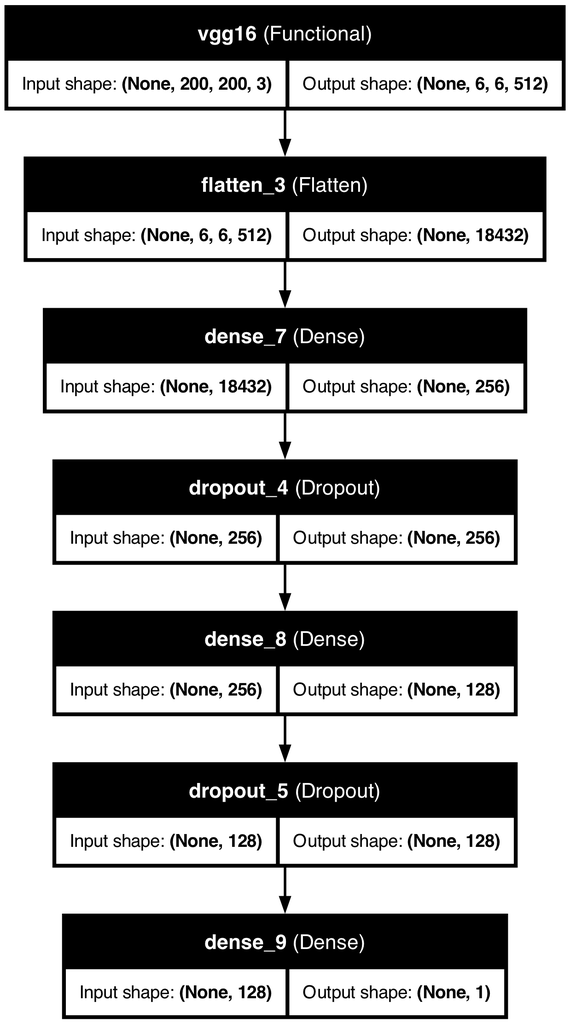

```python
tf.keras.utils.plot_model(vgg_data_aug, show_shapes=True, show_layer_names=True)
```

The VGG16 base contributes over 14.7 million non-trainable parameters, outputting a feature map of shape (6, 6, 512). This is flattened into a 1D vector of 18,432 elements, which feeds into two fully connected layers: the first with 256 units (4.7M parameters) and the second with 128 units (32.9K parameters), both using ReLU activation and followed by 50% dropout for regularization. The final Dense layer has a single sigmoid-activated neuron for binary classification. In total, the model comprises approximately 19.5 million parameters, of which 4.75 million are trainable—allowing the classifier to adapt while preserving the representational power of the frozen VGG16 backbone.

```python
# Compiling the model
vgg_data_aug.compile(optimizer='adam',
              loss='binary_crossentropy',
              metrics=['accuracy', 'precision'])
```